# EDA - Zaclona

Weronika Zacłona

2026-01-13

## Wprowadzenie

W moim projekcie wykorzystuję dane z Kaggle dotyczące *wypraw wspinaczkowych w Himalajach na terenie Nepalu.* Zbiór obejmuje wyprawy od 1905 roku do wiosny 2019 roku i dotyczy ponad 465 znaczących szczytów, w tym również szczytów granicznych, takich jak Mount Everest czy Kangchenjunga. Dane są dostępne w dwóch plikach: jeden opisuje same ekspedycje (m.in. rok, sezon, szczyt, maksymalną osiągniętą wysokość, przyczynę zakończenia, liczbę uczestników i zgony), a drugi zawiera informacje o uczestnikach tych wypraw.

Na potrzeby analizy połączyłam oba pliki w jeden zestaw danych, tak aby dla każdego uczestnika mieć dopisany kontekst wyprawy, w której brał udział. Dzięki temu mogę później analizować zjawiska zarówno na poziomie osób (np. rola, płeć), jak i na poziomie wypraw lub gór (np. sezon, rok, przyczyna zakończenia, śmiertelność i sukcesy)

## Przygotowanie danych

```r
head(expeditions)
```

```
## # A tibble: 6 × 16
##   expedition_id peak_id peak_name     year season basecamp_date highpoint_date
##   <chr>         <chr>   <chr>        <dbl> <chr>  <date>        <date>
## 1 ANN260101     ANN2    Annapurna II  1960 Spring 1960-03-15    1960-05-17
## 2 ANN269301     ANN2    Annapurna II  1969 Autumn 1969-09-25    1969-10-22
## 3 ANN273101     ANN2    Annapurna II  1973 Spring 1973-03-16    1973-05-06
## 4 ANN278301     ANN2    Annapurna II  1978 Autumn 1978-09-08    1978-10-02
## 5 ANN279301     ANN2    Annapurna II  1979 Autumn NA            1979-10-18
## 6 ANN280101     ANN2    Annapurna II  1980 Spring 1980-03-25    1980-04-24
## # ℹ 9 more variables: termination_date <date>, termination_reason <chr>,
## #   highpoint_metres <dbl>, members <dbl>, member_deaths <dbl>,
## #   hired_staff <dbl>, hired_staff_deaths <dbl>, oxygen_used <lgl>,
## #   trekking_agency <chr>
```

```r
head(members)
```

```
## # A tibble: 6 × 21
##   expedition_id member_id peak_id peak_name  year season sex     age citizenship
##   <chr>         <chr>     <chr>   <chr>     <dbl> <chr>  <chr> <dbl> <chr>
## 1 AMAD78301     AMAD7830… AMAD    Ama Dabl…  1978 Autumn M        40 France
## 2 AMAD78301     AMAD7830… AMAD    Ama Dabl…  1978 Autumn M        41 France
## 3 AMAD78301     AMAD7830… AMAD    Ama Dabl…  1978 Autumn M        27 France
## 4 AMAD78301     AMAD7830… AMAD    Ama Dabl…  1978 Autumn M        40 France
## 5 AMAD78301     AMAD7830… AMAD    Ama Dabl…  1978 Autumn M        34 France
## 6 AMAD78301     AMAD7830… AMAD    Ama Dabl…  1978 Autumn M        25 France
## # ℹ 12 more variables: expedition_role <chr>, hired <lgl>,
## #   highpoint_metres <dbl>, success <lgl>, solo <lgl>, oxygen_used <lgl>,
## #   died <lgl>, death_cause <chr>, death_height_metres <dbl>, injured <lgl>,
## #   injury_type <chr>, injury_height_metres <dbl>
```

```r
expeditions %>% count(expedition_id) %>% filter(n>1)
```

```
## # A tibble: 1 × 2
##   expedition_id     n
##   <chr>         <int>
## 1 KANG10101         2
```

```r
expeditions %>% filter(expedition_id == "KANG10101")
```

```
## # A tibble: 2 × 16
##   expedition_id peak_id peak_name      year season basecamp_date highpoint_date
##   <chr>         <chr>   <chr>         <dbl> <chr>  <date>        <date>
## 1 KANG10101     KANG    Kangchenjunga  1910 Spring NA            NA
## 2 KANG10101     KANG    Kangchenjunga  2010 Spring 2010-03-24    2010-04-29
## # ℹ 9 more variables: termination_date <date>, termination_reason <chr>,
## #   highpoint_metres <dbl>, members <dbl>, member_deaths <dbl>,
## #   hired_staff <dbl>, hired_staff_deaths <dbl>, oxygen_used <lgl>,
## #   trekking_agency <chr>
```

```r
expeditions <- expeditions %>% filter(!(expedition_id =="KANG10101" & year== 1910))
```

Podczas łączenia danych pojawiła się relacja wiele do wielu, ponieważ jeden identyfikator wyprawy (KANG10101) występował w tabeli expeditions dwukrotnie. Po sprawdzeniu okazało się, że rekord z 1910 roku (oznaczony jako „Did not attempt climb”) zawierał liczne braki danych, dlatego został usunięty przed dalszą analizą.

```r
dane <- members %>% left_join(expeditions,by = "expedition_id")
colnames(dane)
```

```
##  [1] "expedition_id"        "member_id"            "peak_id.x"
##  [4] "peak_name.x"          "year.x"               "season.x"
##  [7] "sex"                  "age"                  "citizenship"
## [10] "expedition_role"      "hired"                "highpoint_metres.x"
## [13] "success"              "solo"                 "oxygen_used.x"
## [16] "died"                 "death_cause"          "death_height_metres"
## [19] "injured"              "injury_type"          "injury_height_metres"
## [22] "peak_id.y"            "peak_name.y"          "year.y"
## [25] "season.y"             "basecamp_date"        "highpoint_date"
## [28] "termination_date"     "termination_reason"   "highpoint_metres.y"
## [31] "members"              "member_deaths"        "hired_staff"
## [34] "hired_staff_deaths"   "oxygen_used.y"        "trekking_agency"
```

```r
dane <- dane %>%
  select(
    expedition_id,
    peak_name = peak_name.y,
    year = year.y,
    season = season.y,
    sex,
    age,
    died,
    success,
    oxygen_used = oxygen_used.y,
    trekking_agency,
    termination_reason,
    injured,
    injury_height_metres,
    death_height_metres,
    highpoint_metres = highpoint_metres.y,
    expedition_role
  )
```

Po połączeniu danych ograniczyłam zbiór do kolumn istotnych dla moich pytań badawczych, żeby ułatwić dalszą analizę.

```r
head(dane,4)
```

```
## # A tibble: 4 × 16
##   expedition_id peak_name   year season sex     age died  success oxygen_used
##   <chr>         <chr>      <dbl> <chr>  <chr> <dbl> <lgl> <lgl>   <lgl>
## 1 AMAD78301     Ama Dablam  1978 Autumn M        40 FALSE FALSE   FALSE
## 2 AMAD78301     Ama Dablam  1978 Autumn M        41 FALSE FALSE   FALSE
## 3 AMAD78301     Ama Dablam  1978 Autumn M        27 FALSE FALSE   FALSE
## 4 AMAD78301     Ama Dablam  1978 Autumn M        40 FALSE FALSE   FALSE
## # ℹ 7 more variables: trekking_agency <chr>, termination_reason <chr>,
## #   injured <lgl>, injury_height_metres <dbl>, death_height_metres <dbl>,
## #   highpoint_metres <dbl>, expedition_role <chr>
```

```r
tail(dane,4)
```

```
## # A tibble: 4 × 16
##   expedition_id peak_name     year season sex     age died  success oxygen_used
##   <chr>         <chr>        <dbl> <chr>  <chr> <dbl> <lgl> <lgl>   <lgl>
## 1 RATC19101     Ratna Chuli   2019 Spring M        55 FALSE FALSE   FALSE
## 2 SANK19101     Sano Kailash  2019 Spring M        56 FALSE TRUE    FALSE
## 3 SANK19101     Sano Kailash  2019 Spring F        57 FALSE FALSE   FALSE
## 4 SANK19101     Sano Kailash  2019 Spring M        41 FALSE TRUE    FALSE
## # ℹ 7 more variables: trekking_agency <chr>, termination_reason <chr>,
## #   injured <lgl>, injury_height_metres <dbl>, death_height_metres <dbl>,
## #   highpoint_metres <dbl>, expedition_role <chr>
```

```r
str(dane)
```

```
## tibble [76,519 × 16] (S3: tbl_df/tbl/data.frame)
##  $ expedition_id       : chr [1:76519] "AMAD78301" "AMAD78301" "AMAD78301" "AMAD78301" ...
##  $ peak_name           : chr [1:76519] "Ama Dablam" "Ama Dablam" "Ama Dablam" "Ama Dablam" ...
##  $ year                : num [1:76519] 1978 1978 1978 1978 1978 ...
##  $ season              : chr [1:76519] "Autumn" "Autumn" "Autumn" "Autumn" ...
##  $ sex                 : chr [1:76519] "M" "M" "M" "M" ...
##  $ age                 : num [1:76519] 40 41 27 40 34 25 41 29 35 37 ...
##  $ died                : logi [1:76519] FALSE FALSE FALSE FALSE FALSE FALSE ...
##  $ success             : logi [1:76519] FALSE FALSE FALSE FALSE FALSE FALSE ...
##  $ oxygen_used         : logi [1:76519] FALSE FALSE FALSE FALSE FALSE FALSE ...
##  $ trekking_agency     : chr [1:76519] NA NA NA NA ...
##  $ termination_reason  : chr [1:76519] "Bad conditions (deep snow, avalanching, falling ice, or rock)" "Bad conditions (deep snow, avalanching, falling ice, or rock)" "Bad conditions (deep snow, avalanching, falling ice, or rock)" "Bad conditions (deep snow, avalanching, falling ice, or rock)" ..…
##  $ injured             : logi [1:76519] FALSE FALSE FALSE FALSE FALSE FALSE ...
##  $ injury_height_metres: num [1:76519] NA NA NA NA NA NA NA NA NA NA ...
##  $ death_height_metres : num [1:76519] NA NA NA NA NA NA NA NA NA NA ...
##  $ highpoint_metres    : num [1:76519] 6000 6000 6000 6000 6000 ...
##  $ expedition_role     : chr [1:76519] "Leader" "Deputy Leader" "Climber" "Exp Doctor" ...
```

```r
dane$sex <- as.factor(dane$sex)
dane$season <- as.factor(dane$season)
dane$expedition_role <- as.factor(dane$expedition_role)
dane$termination_reason <- as.factor(dane$termination_reason)
dane$peak_name <- as.factor(dane$peak_name)
```

Na etapie przygotowania danych część zmiennych tekstowych, takich jak płeć, sezon, rola uczestnika, przyczyna zakończenia wyprawy oraz nazwa szczytu, została przekształcona do postaci zmiennych kategorycznych (factor), co ułatwia dalszą analizę.

## Braki danych

```r
summary(dane)
```

```
##  expedition_id             peak_name          year          season
##  Length:76519       Everest     :21813   Min.   :1905   Autumn :35895
##  Class :character   Cho Oyu     : 8890   1st Qu.:1991   Spring :37782
##  Mode  :character   Ama Dablam  : 8406   Median :2004   Summer :  740
##                     Manaslu     : 4593   Mean   :2000   Unknown:    1
##                     Dhaulagiri I: 2592   3rd Qu.:2012   Winter : 2101
##                     (Other)     :30210   Max.   :2019
##                     NA's        :   15
##    sex             age           died          success        oxygen_used
##  F   : 7044   Min.   : 7.00   Mode :logical   Mode :logical   Mode :logical
##  M   :69473   1st Qu.:29.00   FALSE:75413     FALSE:47320     FALSE:45450
##  NA's:    2   Median :36.00   TRUE :1106      TRUE :29199     TRUE :31069
##               Mean   :37.33
##               3rd Qu.:44.00
##               Max.   :85.00
##               NA's   :3497
##  trekking_agency
##  Length:76519
##  Class :character
##  Mode  :character
##
##
##
##
##                                                                     termination_reason
##  Success (main peak)                                                         :48023
##  Bad weather (storms, high winds)                                            : 8550
##  Bad conditions (deep snow, avalanching, falling ice, or rock)               : 7072
##  Route technically too difficult, lack of experience, strength, or motivation: 2592
##  Other                                                                       : 2166
##  Accident (death or serious injury)                                          : 2151
##  (Other)                                                                     : 5965
##   injured        injury_height_metres death_height_metres highpoint_metres
##  Mode :logical   Min.   : 400         Min.   : 400        Min.   :3500
##  FALSE:74806     1st Qu.:6200         1st Qu.:5800        1st Qu.:6814
##  TRUE :1713      Median :7100         Median :6600        Median :7800
##                  Mean   :7050         Mean   :6593        Mean   :7610
##                  3rd Qu.:8000         3rd Qu.:7550        3rd Qu.:8516
##                  Max.   :8880         Max.   :8830        Max.   :8850
##                  NA's   :75510        NA's   :75451       NA's   :1701
##       expedition_role
##  Climber      :44667
##  H-A Worker   :14489
##  Leader       :10036
##  Exp Doctor   : 1450
##  Deputy Leader: 1238
##  (Other)      : 4618
##  NA's         :   21
```

```r
sort(colSums(is.na(dane)), decreasing = TRUE)
```

```
## injury_height_metres  death_height_metres      trekking_agency
##                75510                75451                13467
##                  age     highpoint_metres      expedition_role
##                 3497                 1701                   21
##            peak_name                  sex        expedition_id
##                   15                    2                    0
##                 year               season                 died
##                    0                    0                    0
##              success          oxygen_used   termination_reason
##                    0                    0                    0
##              injured
##                    0
```

```r
table(dane$injured,is.na(dane$injury_height_metres))
```

```
##
##         FALSE  TRUE
##   FALSE     0 74806
##   TRUE   1009   704
```

```r
table(dane$died,is.na(dane$death_height_metres))
```

```
##
##         FALSE  TRUE
##   FALSE     0 75413
##   TRUE   1068    38
```

W danych widoczna jest duża liczba braków w zmiennych injury_height_metres oraz death_height_metres. Wynika to jednak z charakteru tych zmiennych. Wysokość kontuzji jest podawana tylko wtedy, gdy doszło do urazu, a wysokość zgonu tylko w przypadku śmierci uczestnika. Braki te są więc naturalne. *Braki faktyczne to 704 w injury_height_metres i 38 w death_height_metres.* Na tym etapie analizy nie usuwano pozostałych braków danych. Zamiast tego braki będą uwzględniane indywidualnie w zależności od konkretnego pytania badawczego.

## Pytanie badawcze 1

### Które szczyty są najbardziej śmiercionośne?

```r
smiercionosnosc_peak <- dane %>% filter(!is.na(peak_name)) %>%
  group_by(peak_name) %>% summarise(
    n_osob = length(died),
    zgony = sum(died == TRUE),
    wsk_smiert = mean(died == TRUE)
  )
smiercionosnosc_peak %>% arrange(desc(zgony)) %>% head(10)
```

```
## # A tibble: 10 × 4
##    peak_name     n_osob zgony wsk_smiert
##    <fct>          <int> <int>      <dbl>
##  1 Everest        21813   306    0.0140
##  2 Dhaulagiri I    2592    85    0.0328
##  3 Manaslu         4593    85    0.0185
##  4 Annapurna I     1669    72    0.0431
##  5 Cho Oyu         8890    52    0.00585
##  6 Kangchenjunga   1385    51    0.0368
##  7 Makalu          2405    48    0.0200
##  8 Pumori          1780    42    0.0236
##  9 Ama Dablam      8406    32    0.00381
## 10 Lhotse          2379    21    0.00883
```

```r
smiercionosnosc_peak %>% arrange(desc(wsk_smiert)) %>% head(10)
```

```
## # A tibble: 10 × 4
##    peak_name                n_osob zgony wsk_smiert
##    <fct>                     <int> <int>      <dbl>
##  1 Pisang                       13    11     0.846
##  2 Mardi Himal                   6     1     0.167
##  3 Gurja Himal                  95    13     0.137
##  4 Hiunchuli                    41     5     0.122
##  5 Ganesh V                     36     4     0.111
##  6 Dhaulagiri IV               129    14     0.109
##  7 Himalchuli North             28     3     0.107
##  8 Thulagi                      35     3     0.0857
##  9 Firnkopf                     12     1     0.0833
## 10 Kande Hiunchuli North  I     12     1     0.0833
```

Surowy ranking (z szczytem Pisang na czele) jest niemiarodajny, ponieważ przy bardzo małej liczbie uczestników na przykład tak jak w przypadku Pisang n = 13, pojedynczy wypadek generuje ekstremalny wskaźnik śmiertelności.

```r
quantile(smiercionosnosc_peak$n_osob,c(0.5,0.75,0.9,0.95))
```

```
##    50%    75%    90%    95%
##  19.00  49.00 129.00 290.85
```

W celu ograniczenia wpływu losowych wahań wskaźnika śmiertelności, do dalszej analizy uwzględniono jedynie te szczyty, dla których liczba uczestników wypraw przekracza wartość 90. kwantyla rozkładu zmiennej n_osob (około 130 osób).

Taki próg zapewnia względnie stabilne estymacje wskaźnika śmiertelności, jednocześnie nie zawężając analizy wyłącznie do najbardziej popularnych, komercyjnych szczytów (takich jak Mount Everest). Pozwala to objąć analizą również góry rzadziej odwiedzane, ale nadal posiadające wystarczającą liczbę obserwacji.

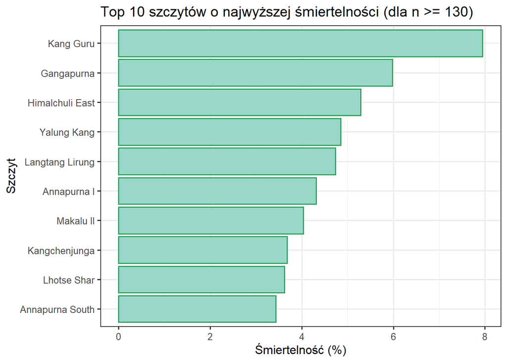

```r
wykres_dane <- smiercionosnosc_peak %>%
  filter(n_osob >= 130) %>%
  arrange(desc(wsk_smiert)) %>%
  head(10)
wykres_dane <- wykres_dane %>% mutate(wsk_smiert = wsk_smiert * 100)
ggplot(wykres_dane, aes(x = wsk_smiert, y = reorder(peak_name,wsk_smiert))) + geom_col(fill = "#99d8c9",color = "#2ca25f") + labs(title = "Top 10 szczytów o najwyższej śmiertelności (dla n >= 130)", x = "Śmiertelność (%)", y = "Szczyt") + theme_bw(base_size = 12)
```

Wyniki pokazują, że po uwzględnieniu tylko szczytów z wystarczająco dużą liczbą uczestników (n ≥ 130) najbardziej śmiercionośny okazuje się **Kang Guru**. Tak wysoki wskaźnik śmiertelności nie musi jednak oznaczać, że góra ta jest wyjątkowo niebezpieczna.W dużej mierze wynika on z pojedynczego, tragicznego zdarzenia. W 2005 roku w bazie pod Kang Guru doszło do lawiny, w której zginęło kilkanaście osób, co silnie podbiło procentowy wskaźnik śmiertelności w danych.

Dla porównania **Mount Everest** ma zdecydowanie największą liczbę zgonów w wartościach bezwzględnych, ale przy bardzo dużej liczbie uczestników jego śmiertelność liczona w procentach jest relatywnie niska. Pokazuje to, że ranking oparty na samych liczbach zgonów jest silnie zdominowany przez popularność szczytu, natomiast analiza procentowa lepiej oddaje ryzyko przypadające na jednego uczestnika. Obecność takich gór jak Annapurna I czy Kangchenjunga w czołówce wskazuje, że są to szczyty trudniejsze i bardziej niebezpieczne.

## Pytanie badawcze 2

### Czy ryzyko śmierci zależy od sezonu wyprawy?

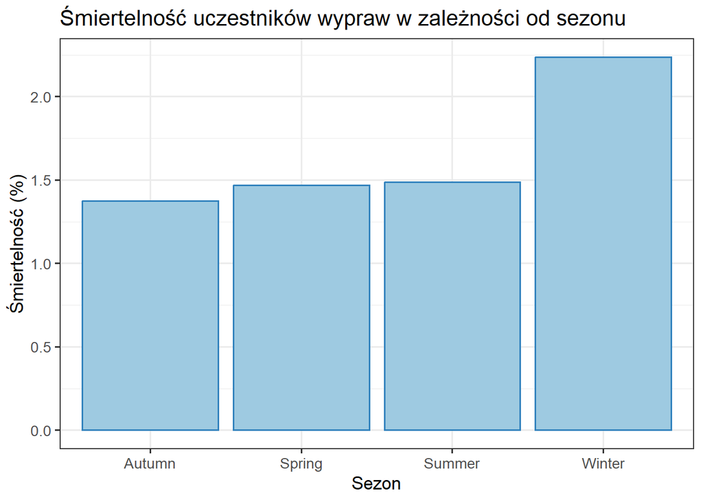

```r
sezon_smierc <- dane %>% filter(season != "Unknown") %>% group_by(season) %>% summarise(n_osob = n(), zgony = sum(died == TRUE),wsk_smiert = mean(died == TRUE))
sezon_smierc <- sezon_smierc %>% mutate(wsk_smiert = wsk_smiert * 100)

ggplot(sezon_smierc,aes(x = reorder(season,wsk_smiert),y = wsk_smiert)) + geom_col(fill = "#9ecae1",color = "#3182bd") + labs(title="Śmiertelność uczestników wypraw w zależności od sezonu",x = "Sezon",y = "Śmiertelność (%)") + theme_bw(base_size = 13)
```

```r
dane_sezon <- dane%>% filter(season != "Unknown") %>% mutate(season = droplevels(season))
tablica <- table(dane_sezon$season,dane_sezon$died)
chisq.test(tablica)
```

```
##
##  Pearson's Chi-squared test
##
## data:  tablica
## X-squared = 10.703, df = 3, p-value = 0.01344
```

```r
cramerV(tablica)
```

```
## Cramer V
##  0.01183
```

Aby sprawdzić, czy ryzyko śmierci zależy od pory roku, zastosowano test niezależności chi-kwadrat dla zmiennych season oraz died. Przed analizą usunięto obserwacje z sezonem Unknown, a następnie użyto funkcji droplevels(), aby usunąć niewykorzystywany poziom faktora. Bez tego test zwracał wartości NaN, mimo że w danych nie brakowało obserwacji.

Wynik testu **(p-value = 0.013)** wskazuje na istotną statystycznie zależność między sezonem a ryzykiem śmierci. Najniższą śmiertelność odnotowano *jesienią, następnie wiosną, natomiast wyższe ryzyko występuje latem i najwyższe zimą.*

Podwyższona śmiertelność zimą jest zgodna z intuicją i wynika z ekstremalnych warunków pogodowych, natomiast relatywnie gorsze wyniki lata mogą być związane z porą monsunową, charakteryzującą się intensywnymi opadami i zwiększonym ryzykiem lawin.

Jednak aby zbadać siłę zależności między porą roku a ryzkiem śmierci zastosowałam miarę V - Cramera i ta zależńość okazała się bardzo słaba.

## Pytanie badawcze 3

### Czy maksymalna osiągnięta wysokość różniła się między osobami, które przeżyły wyprawę, a tymi, które zginęły?

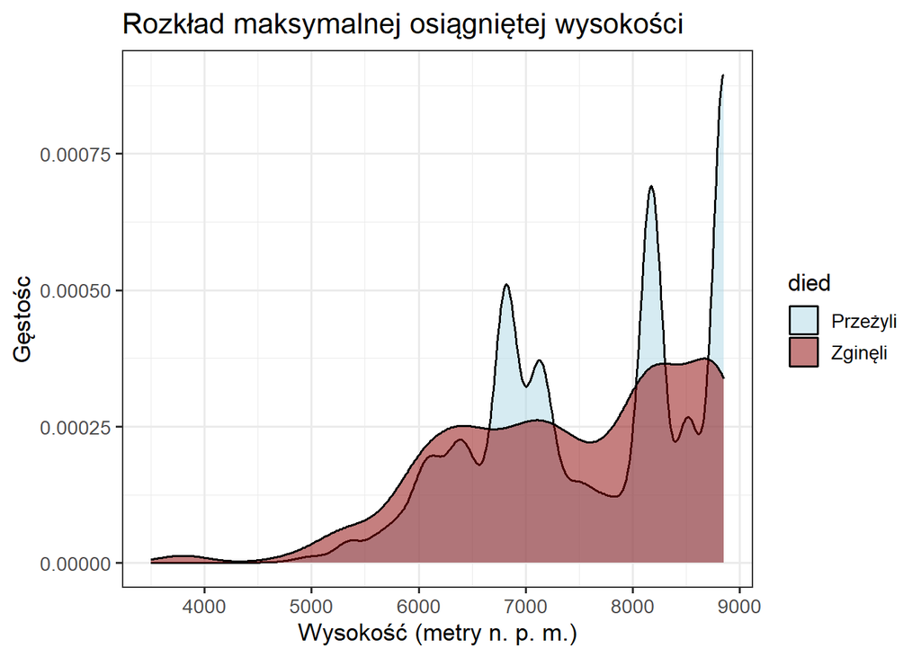

```r
dane %>% filter(!is.na(highpoint_metres)) %>% ggplot(aes(x = highpoint_metres,fill = died)) + geom_density(alpha = 0.5) +
  scale_fill_manual(values = c("lightblue","darkred"),labels = c("Przeżyli","Zginęli")) + labs(title = "Rozkład maksymalnej osiągniętej wysokości", x = "Wysokość (metry n. p. m.)", y = "Gęstośc") + theme_bw(base_size = 13)
```

Ze względu na kształt rozkładów widoczny na wykresie gęstości, zamiast testu t-Studenta zastosowałam nieparametryczny test Wilcoxona.

```r
wilcox.test(
  dane$highpoint_metres[dane$died == TRUE],
  dane$highpoint_metres[dane$died == FALSE]
)
```

```
##
##  Wilcoxon rank sum test with continuity correction
##
## data:  dane$highpoint_metres[dane$died == TRUE] and dane$highpoint_metres[dane$died == FALSE]
## W = 36661757, p-value = 3.262e-06
## alternative hypothesis: true location shift is not equal to 0
```

Wynik testu Wilcoxona wskazuje na istotną statystycznie różnicę pomiędzy grupami **(p < 0.001)**, co oznacza, że typowa maksymalna osiągnięta wysokość różni się między osobami, które przeżyły wyprawę, a tymi, które zginęły

```r
dane %>% filter(!is.na(highpoint_metres),!is.na(died)) %>% group_by(died) %>% summarise(n = n(), mediana = median(highpoint_metres), IQR = IQR(highpoint_metres)
)
```

```
## # A tibble: 2 × 4
##   died      n mediana   IQR
##   <lgl> <int>   <dbl> <dbl>
## 1 FALSE 73735    7800  1702
## 2 TRUE   1083    7600  1985
```

Mediana wysokości była wyższa u ocalałych (7800 m) niż u zmarłych (7600 m), a większy IQR w grupie zgonów wskazuje na bardziej rozproszony zakres wysokości, na których dochodziło do zgonów.

## Pytanie badawcze 4

### Czy ryzyko śmierci różniło się w zależności od roli uczestnika wyprawy?

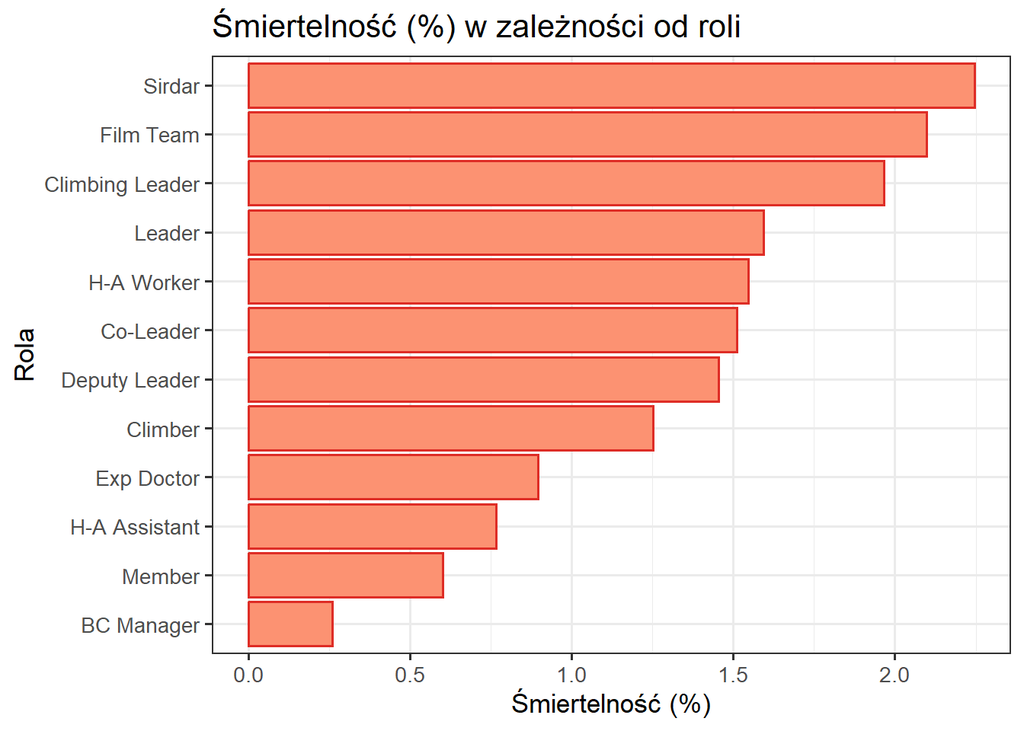

```r
role <- dane %>% filter(!is.na(expedition_role)) %>% group_by(expedition_role) %>% summarise(n = n(), zgony = sum(died == TRUE), smiertelnosc = mean(died == TRUE) * 100)

role12 <- role %>% top_n(12,wt = n) %>% arrange(desc(smiertelnosc))

ggplot(role12, aes(x = smiertelnosc,y = reorder(expedition_role,smiertelnosc))) + geom_col(fill = "#fc9272",color= "#de2d26") + labs(title = "Śmiertelność (%) w zależności od roli",x = "Śmiertelność (%)",y = "Rola") + theme_bw(base_size = 13)
```

Najwyższa śmiertelność wśród **Sirdarów** (lokalnych szefów ekip wysokogórskich) oraz liderów wspinaczki może sugerować, że to na najbardziej doświadczonych osobach spoczywa największe ryzyko. Może to wynikać nie tylko z faktu przecierania szlaków i dłuższego czasu ekspozycji na trudne warunki, ale również z poczucia odpowiedzialności za grupę wysoka śmiertelność w tej grupie prawdopodobnie wiąże się z próbami ratowania pozostałych członków wyprawy, co naraża liderów na dodatkowe niebezpieczeństwo. Zaskakująco wysoka pozycja **ekip filmowych** pozwala przypuszczać, że operowanie ciężkim sprzętem i skupienie na dokumentacji wyprawy mogą utrudniać szybką reakcję w sytuacjach kryzysowych. Z kolei stosunkowo niskie wskaźniki u zwykłych uczestników (Member) oraz menedżerów bazy mogą wskazywać na skuteczność systemów wsparcia i mniejszą ekspozycję tych osób na najbardziej ryzykowne zadania.

## Pytanie badawcze 5

### Czy użycie tlenu z butli realnie zwiększa szanse na przeżycie w “strefie śmierci”?

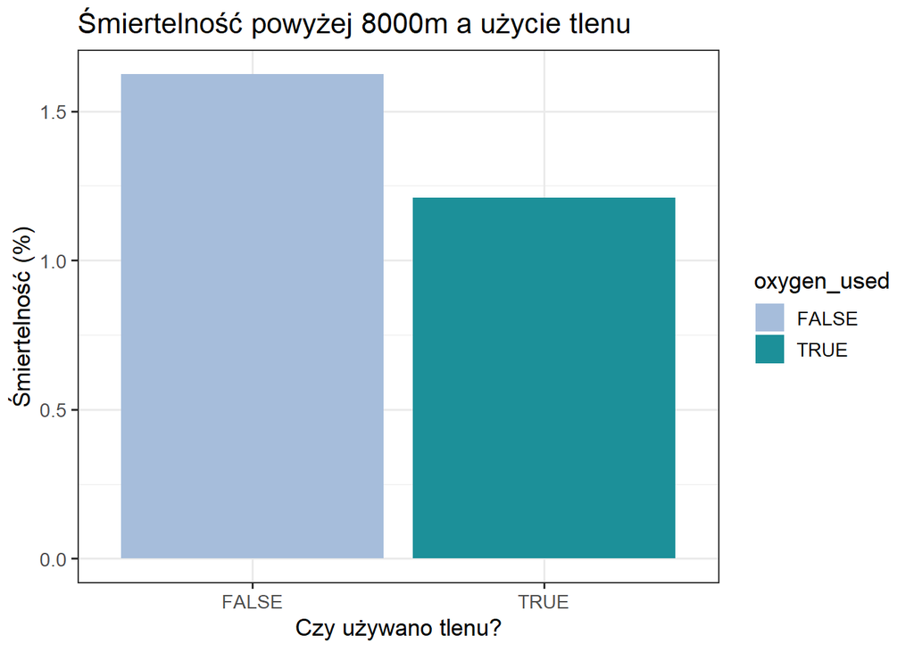

```r
strefa_smierci <- dane %>%filter(highpoint_metres >= 8000) %>% group_by(oxygen_used) %>% summarise(n = n(), zgony = sum(died == TRUE), smiertelnosc = mean(died == TRUE)*100)

ggplot(strefa_smierci, aes(x = oxygen_used, y = smiertelnosc, fill = oxygen_used)) +
  geom_col() +
  scale_fill_manual(values = c("#a6bddb", "#1c9099")) +
  labs(title = "Śmiertelność powyżej 8000m a użycie tlenu",
       x = "Czy używano tlenu?", y = "Śmiertelność (%)") +
  theme_bw(base_size = 13)
```

```r
prop.test(strefa_smierci$zgony,strefa_smierci$n)
```

```
##
##  2-sample test for equality of proportions with continuity correction
##
## data:  strefa_smierci$zgony out of strefa_smierci$n
## X-squared = 7.9156, df = 1, p-value = 0.004901
## alternative hypothesis: two.sided
## 95 percent confidence interval:
##  0.0009947649 0.0073016748
## sample estimates:
##     prop 1     prop 2
## 0.01625190 0.01210368
```

Na wykresie widać, że używanie tlenu faktycznie zwiększa szanse na przeżycie. Jest to o tyle ciekawe, że teoretycznie można by przypuszczać coś odwrotnego, że tlen zachęca mniej doświadczone osoby do porywania się na zbyt wysokie szczyty, co mogłoby podbijać statystyki zgonów. Okazuje się jednak, że korzyści fizjologiczne z oddychania z butli tlenowej są silniejsze niż to ryzyko. Wynik testu proporcji dodatkowo potwierdza tę różnicę statystycznie **(p<0.05).** Oznacza to, że użycie tlenu z butli może istotnie wpływać na szanse przeżycia w strefie śmierci.

## Pytanie badawcze 6

### Czy wiek uczestnika wpływał na maksymalną osiągniętą wysokość?

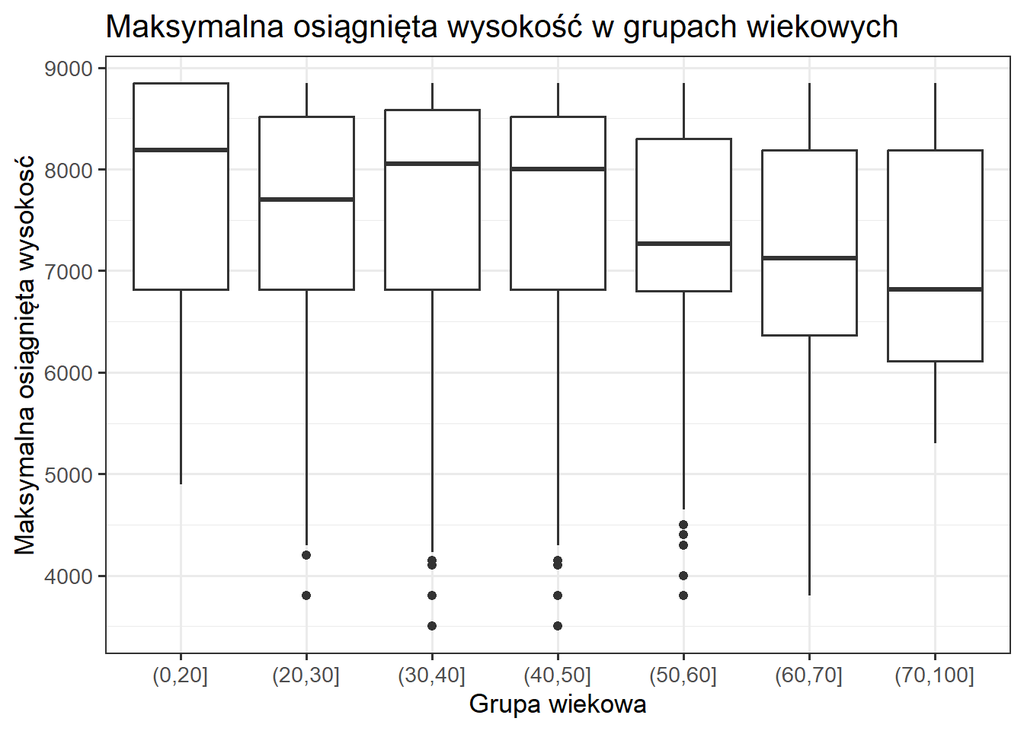

```r
dane_wiek <- dane%>% filter(!is.na(age), !is.na(highpoint_metres))

dane_wiek <- dane_wiek %>% mutate(age_klasy = cut(age,breaks = c(0,20,30,40,50,60,70,100)))

ggplot(dane_wiek, aes(x = age_klasy,y=highpoint_metres)) + geom_boxplot() + labs(title = "Maksymalna osiągnięta wysokość w grupach wiekowych",x = "Grupa wiekowa",y = "Maksymalna osiągnięta wysokosć") + theme_bw(base_size = 13)
```

```r
tapply(dane_wiek$highpoint_metres, dane_wiek$age_klasy,lillie.test)
```

```
## $`(0,20]`
##
##  Lilliefors (Kolmogorov-Smirnov) normality test
##
## data:  X[[i]]
## D = 0.20062, p-value < 2.2e-16
##
##
## $`(20,30]`
##
##  Lilliefors (Kolmogorov-Smirnov) normality test
##
## data:  X[[i]]
## D = 0.13866, p-value < 2.2e-16
##
##
## $`(30,40]`
##
##  Lilliefors (Kolmogorov-Smirnov) normality test
##
## data:  X[[i]]
## D = 0.16151, p-value < 2.2e-16
##
##
## $`(40,50]`
##
##  Lilliefors (Kolmogorov-Smirnov) normality test
##
## data:  X[[i]]
## D = 0.16878, p-value < 2.2e-16
##
##
## $`(50,60]`
##
##  Lilliefors (Kolmogorov-Smirnov) normality test
##
## data:  X[[i]]
## D = 0.16182, p-value < 2.2e-16
##
##
## $`(60,70]`
##
##  Lilliefors (Kolmogorov-Smirnov) normality test
##
## data:  X[[i]]
## D = 0.15502, p-value < 2.2e-16
##
##
## $`(70,100]`
##
##  Lilliefors (Kolmogorov-Smirnov) normality test
##
## data:  X[[i]]
## D = 0.13987, p-value = 5.94e-09
```

Chciałam sprawdzić, czy wiek uczestnika wpływa na maksymalną osiągniętą wysokość. Wykres pudełkowy pokazał, że mediany wysokości utrzymują się na podobnym poziomie do 50. roku życia, a później zaczynają wyraźnie spadać. Aby potwierdzić te obserwacje statystycznie, najpierw sprawdziłam założenia niezbędne do przeprowadzenia analizy wariancji.Testy **Lillieforsa** potwierdziły brak rozkładu normalnego we wszystkich grupach wiekowych **(p < 0.05)**. Ponieważ dane nie spełniły zalożeń ANOVY, zdecydowałam się na nieparametryczny test **Kruskala - Wallisa.**

```r
dunn.test(dane_wiek$highpoint_metres,dane_wiek$age_klasy)
```

```
##   Kruskal-Wallis rank sum test
##
## data: x and group
## Kruskal-Wallis chi-squared = 469.6263, df = 6, p-value = 0
##
##
##                            Comparison of x by group
##                                 (No adjustment)
## Col Mean-|
## Row Mean |     (0,20]    (20,30]    (30,40]    (40,50]    (50,60]    (60,70]
## ---------+------------------------------------------------------------------
##  (20,30] |   7.301018
##          |    0.0000*
##  (30,40] |   5.262572  -7.183829
##          |    0.0000*    0.0000*
##  (40,50] |   6.677364  -1.782213   4.800681
##          |    0.0000*     0.0374    0.0000*
##  (50,60] |   10.70827   8.963775   14.06576   9.955845
##          |    0.0000*    0.0000*    0.0000*    0.0000*
##  (60,70] |   13.47393   11.92945   14.72305   12.54286   6.361439
##          |    0.0000*    0.0000*    0.0000*    0.0000*    0.0000*
## (70,100] |   8.748441   6.311823   7.208044   6.553719   4.581164   2.231415
##          |    0.0000*    0.0000*    0.0000*    0.0000*    0.0000*    0.0128*
##
## alpha = 0.05
## Reject Ho if p <= alpha/2
```

## Pytanie badawcze 7

### Czy płeć uczestnika była związana z ryzykiem śmierci podczas wyprawy?

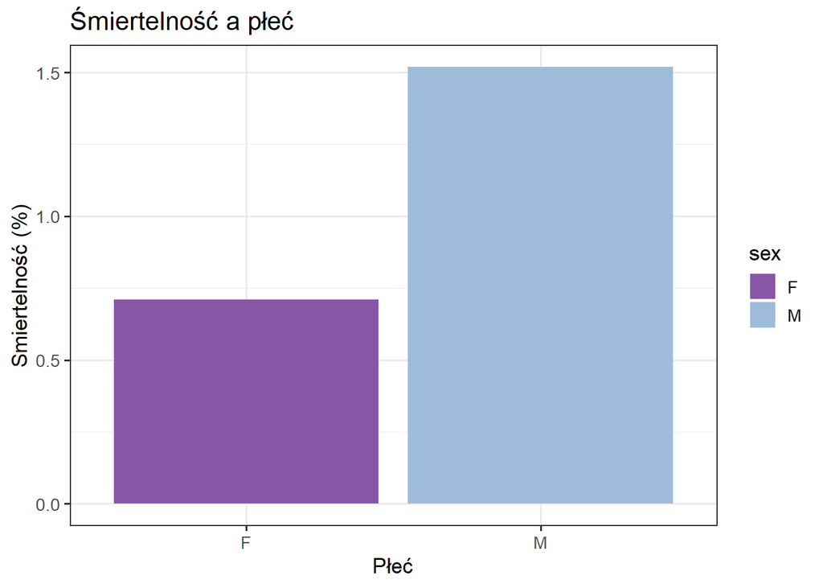

```r
plec_smierc <- dane %>% filter(!is.na(sex)) %>% group_by(sex) %>% summarise(n=n(),zgony = sum(died==TRUE), smiertelnosc = mean(died==TRUE)*100)
ggplot(plec_smierc,aes(x = sex,y = smiertelnosc,fill = sex)) + geom_col() + scale_fill_manual(values =c("F"= "#8856a7","M"="#9ebcda")) + labs(title = "Śmiertelność a płeć",x = "Płeć",y = "Smiertelność (%)") + theme_bw(base_size = 13)
```

```r
 prop.test(plec_smierc$zgony, plec_smierc$n)
```

```
##
##  2-sample test for equality of proportions with continuity correction
##
## data:  plec_smierc$zgony out of plec_smierc$n
## X-squared = 28.904, df = 1, p-value = 7.606e-08
## alternative hypothesis: two.sided
## 95 percent confidence interval:
##  -0.010341401 -0.005862419
## sample estimates:
##     prop 1     prop 2
## 0.00709824 0.01520015
```

Analiza ryzyka zgonu ze względu na płeć podważa przekonanie o mniejszej odporności kobiet na ekstremalne warunki. Dane pokazują, że ich śmiertelność (ok. 0,7%) jest blisko dwukrotnie niższa niż u mężczyzn (ok. 1,5%). Może to wynikać z tego że,na tak trudne wyprawy decydują się prawdopodobnie tylko wybitnie przygotowane i wykwalifikowane kobiety. Trzeba jednak zaznaczyć, że ze względu na małą liczebność grupy żeńskiej, wynik ten jest statystycznie mniej stabilny. Niższy odsetek zgonów u kobiet może świadczyć o ich bardzo rzetelnym przygotowaniu. Natomiast wyżśzy odsetek u mężczyzn może świadczyć o skłonności do bardziej ryzykownych wypraw. Zastosowany test proporcji potwierdził, że obserwowana różnica w śmiertelności pomiędzy kobietami i mężczyznami jest istotna statystycznie **(p < 0.001)**, co wskazuje na istnienie związku między płcią a ryzykiem zgonu w badanej próbie.

## Pytanie badawcze 8

### Czy wraz z upływem lat wspinaczka w Himalajach stała się bezpieczniejsza?

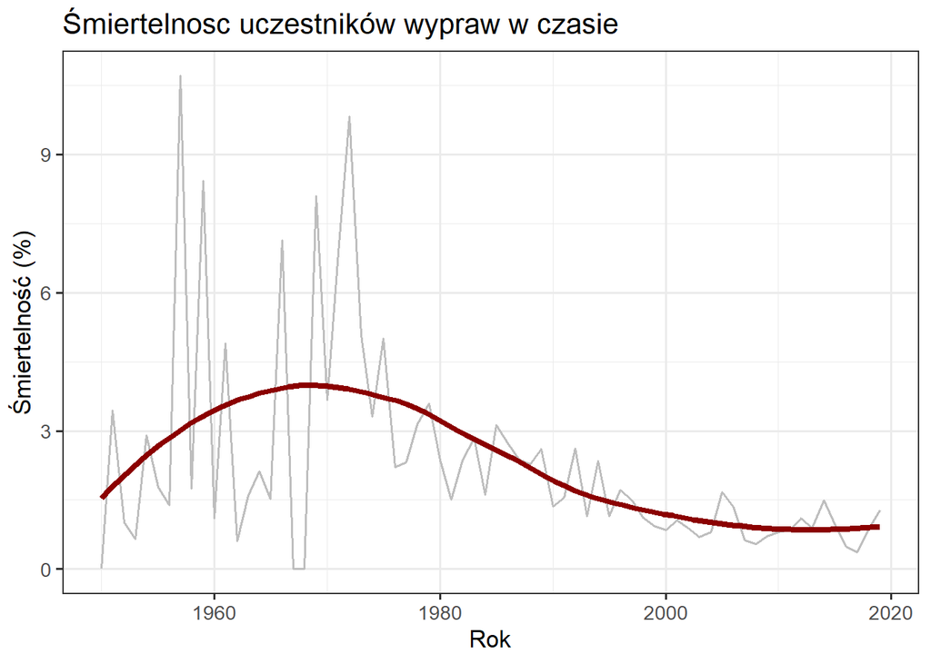

```r
bezpieczenstwo <- dane %>% group_by(year) %>% summarise (n= n(),zgony = sum(died == TRUE),smiertelnosc = mean(died == TRUE)*100) %>% filter(year >=1950)

ggplot(bezpieczenstwo, aes(x = year, y = smiertelnosc)) + geom_line(color = "grey") +geom_smooth(method = "loess",color = "darkred",linewidth = 1.5,se=FALSE)+ labs(title = "Śmiertelnosc uczestników wypraw w czasie", x = "Rok",y = "Śmiertelność (%)") + theme_bw(base_size = 13)
```